# R Notebook

Este conjunto de datos ha sido extraido de Kaggle: https://www.kaggle.com/namanmanchanda/entrepreneurial-competency-in-university-students

```r
df = read.csv("data.csv")

df
```

# cargamos las librerias

```r
library(ggplot2)
library(summarytools)
library(dplyr)
library(plotrix)
library(tidyverse)
library(tokenizers)
```

Disponemos de un conjunto de datos sobre estudiantes universitarios, que han sido analizados, en base a ciertas caracteristicas o aptitudes, con el objetivo de predecir la probabilidad de que acaben siendo emprendedores o no.

El estudio ha establecido una variable objetivo denominada “whether the student is likely to become an entrepreneur or not” (probabilidad de que el estudiante se convierta en empresario o no) formada por dos elementos, 0 - No llega a serlo / 1 - Si llega a serlo.

El problema que intentaremos resolver es determinar, que caracterisiticas, segun este estudio, son determinantes para que un estudiante universitario se convierta en empresario.

# Variables que contiene el dataset:

1 - EducationSector: Tipo de carrera que está cursando el estudiante

2 - IndividualProject: ¿Estaria dispuesto a llevar a cabo un proyecto individual? SI/NO

3 - Age: Edad del encuestado

4 - Gender: Genero del encuestado

5 - City: ¿Vive en una ciudad? SI/NO

6 - Influenced: ¿Le ha influido alguien a la hora de elegir la carrera que está cursando? SI/NO

7 - Perseverance: Nivel de perseverancia o constancia que tiene, del 1 al 5

8 - DesireToTakeInitiative: Nivel de deseo de tomar la iniciativa, del 1 al 5

9 - Competitiveness: Nivel de competitividad, del 1 al 5

10 - SelfReliance: Nivel de autosuficiencia, del 1 al 5

11 - StrongNeedToAchieve: Nivel de necesidad de lograr una meta, del 1 al 5

12 - SelfConfidence: Nivel de autoconfianza, del 1 al 5

13 - GoodPhysicalHealth: Nivel de salud fisica, del 1 al 5

14 - MentalDisorder: ¿Tiene algun trastorno mental? SI/NO

15 - KeyTraits: Cuales son los rasgos claves del encuestado

16 - ReasonsForLack: Cual seria el motivo de la falta de interes en ser emprendedor.

17 - y: Se trata de la variable dependiente que recoge la prediccion de si el estudiante se convertirá en empresario 1, o no se convertirá 0.

# Clasifiacion de las variables en funcion de su escala de medida:

- Todas estas son variables independientes.

1 - Variables categoricas nominales: EducationSector, IndividualProject, Gender, City, Influenced, MentalDisorder, KeyTraits, ReasonsForLack

2 - Variables categoricas ordinales: Perseverance, DesireToTakeInitiative, Competitiveness, SelfReliance, StrongNeedToAchieve, GoodPhysicalHealth, SelfConfidence

3 - Variables cuantitativas discreta: Age

- Variable dependiente.

4 - Variable categorica binomial.

# Preguntas:

¿Que caracterisitica o caracteristicas son determinantes a la hora de emprender?

¿El tipo de carrera que se esté cursando influye a la hora de ser emprendor?

# Analisis descriptivo

```r
summary(df)
```

```
 EducationSector    IndividualProject       Age           Gender
 Length:219         Length:219         Min.   :17.00   Length:219
 Class :character   Class :character   1st Qu.:19.00   Class :character
 Mode  :character   Mode  :character   Median :20.00   Mode  :character
                                       Mean   :19.75
                                       3rd Qu.:20.00
                                       Max.   :26.00
     City            Influenced         Perseverance
 Length:219         Length:219         Min.   :1.000
 Class :character   Class :character   1st Qu.:3.000
 Mode  :character   Mode  :character   Median :3.000
                                       Mean   :3.352
                                       3rd Qu.:4.000
                                       Max.   :5.000
 DesireToTakeInitiative Competitiveness  SelfReliance   StrongNeedToAchieve
 Min.   :1.000          Min.   :1.000   Min.   :1.000   Min.   :1.000
 1st Qu.:3.000          1st Qu.:3.000   1st Qu.:3.000   1st Qu.:3.000
 Median :4.000          Median :4.000   Median :4.000   Median :4.000
 Mean   :3.621          Mean   :3.589   Mean   :3.721   Mean   :3.909
 3rd Qu.:5.000          3rd Qu.:4.500   3rd Qu.:5.000   3rd Qu.:5.000
 Max.   :5.000          Max.   :5.000   Max.   :5.000   Max.   :5.000
 SelfConfidence  GoodPhysicalHealth MentalDisorder      KeyTraits
 Min.   :1.000   Min.   :1.000      Length:219         Length:219
 1st Qu.:3.000   1st Qu.:3.000      Class :character   Class :character
 Median :4.000   Median :4.000      Mode  :character   Mode  :character
 Mean   :3.575   Mean   :3.562
 3rd Qu.:4.000   3rd Qu.:4.000
 Max.   :5.000   Max.   :5.000
 ReasonsForLack           y
 Length:219         Min.   :0.0000
 Class :character   1st Qu.:0.0000
 Mode  :character   Median :0.0000
                    Mean   :0.4155
                    3rd Qu.:1.0000
                    Max.   :1.0000
```

```r
str(df)
```

```
'data.frame':   219 obs. of  17 variables:
 $ EducationSector       : chr  "Engineering Sciences" "Engineering Sciences" "Engineering Sciences" "Engineering Sciences" ...
 $ IndividualProject     : chr  "No" "Yes" "No" "Yes" ...
 $ Age                   : int  19 22 18 20 19 19 19 20 20 17 ...
 $ Gender                : chr  "Male" "Male" "Male" "Male" ...
 $ City                  : chr  "Yes" "No" "Yes" "Yes" ...
 $ Influenced            : chr  "No" "Yes" "No" "Yes" ...
 $ Perseverance          : int  2 3 3 3 2 3 3 4 2 2 ...
 $ DesireToTakeInitiative: int  2 3 4 3 3 3 2 2 3 3 ...
 $ Competitiveness       : int  3 3 3 3 3 3 3 4 3 2 ...
 $ SelfReliance          : int  3 4 3 3 3 3 3 4 1 1 ...
 $ StrongNeedToAchieve   : int  2 4 3 4 4 3 4 5 2 4 ...
 $ SelfConfidence        : int  2 3 4 3 3 3 1 3 2 3 ...
 $ GoodPhysicalHealth    : int  3 4 4 3 2 3 1 4 2 3 ...
 $ MentalDisorder        : chr  "Yes" "Yes" "No" "No" ...
 $ KeyTraits             : chr  "Passion" "Vision" "Passion" "Resilience" ...
 $ ReasonsForLack        : chr  "" "Just not interested! (Want to work in the corporate sector, or for the government or pursue research or something else)" "Not willing to start a venture in India and waiting for future relocation" "Not able to take a Financial Risk" ...
 $ y                     : int  1 0 0 0 1 1 1 0 0 1 ...
```

Disponemos de 219 filas y 17 variables

```r
apply(is.na(df), 2, sum)
```

```
       EducationSector      IndividualProject                    Age
                     0                      0                      0
                Gender                   City             Influenced
                     0                      0                      0
          Perseverance DesireToTakeInitiative        Competitiveness
                     0                      0                      0
          SelfReliance    StrongNeedToAchieve         SelfConfidence
                     0                      0                      0
    GoodPhysicalHealth         MentalDisorder              KeyTraits
                     0                      0                      0
        ReasonsForLack                      y
                     0                      0
```

```r
df$ReasonsForLack = vector(df$ReasonsForLack)
```

[output not shown]

# Comenzamos el analisis de las variables:

# y

La primera variable que vamos a analizar es la variable dependiente

```r
freq(df$y, style= "rmarkdown")
```

```
### Frequencies
#### df$y
**Type:** Factor

|     &nbsp; | Freq | % Valid | % Valid Cum. | % Total | % Total Cum. |
|-----------:|-----:|--------:|-------------:|--------:|-------------:|
|      **0** |  128 |   58.45 |        58.45 |   58.45 |        58.45 |
|      **1** |   91 |   41.55 |       100.00 |   41.55 |       100.00 |
| **\<NA\>** |    0 |         |              |    0.00 |       100.00 |
|  **Total** |  219 |  100.00 |       100.00 |  100.00 |       100.00 |
```

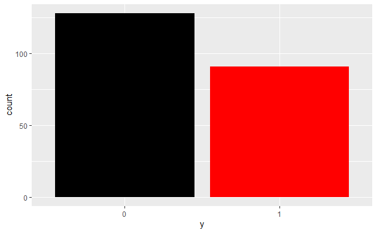

```r
ggplot(df, aes(y)) + geom_bar(fill = c("black", "red"))
```

Vamos a comenzar a analizar las variables dependientes, tanto de forma individual como relacionadas con la variable dependiente

# EducationSector

```r
freq(df$EducationSector, style = "rmarkdown")
```

```
### Frequencies
#### df$EducationSector
**Type:** Factor

|                                                    &nbsp; | Freq | % Valid | % Valid Cum. | % Total | % Total Cum. |
|----------------------------------------------------------:|-----:|--------:|-------------:|--------:|-------------:|
|                                  **Art, Music or Design** |   21 |    9.59 |         9.59 |    9.59 |         9.59 |
| **Economic Sciences, Business Studies, Commerce and Law** |   32 |   14.61 |        24.20 |   14.61 |        24.20 |
|                                  **Engineering Sciences** |  123 |   56.16 |        80.37 |   56.16 |        80.37 |
|                        **Humanities and Social Sciences** |    5 |    2.28 |        82.65 |    2.28 |        82.65 |
|                         **Language and Cultural Studies** |    1 |    0.46 |        83.11 |    0.46 |        83.11 |
|                       **Mathematics or Natural Sciences** |    4 |    1.83 |        84.93 |    1.83 |        84.93 |
|                             **Medicine, Health Sciences** |   10 |    4.57 |        89.50 |    4.57 |        89.50 |
|                                                **Others** |   20 |    9.13 |        98.63 |    9.13 |        98.63 |
|                          **Teaching Degree (e.g., B.Ed)** |    3 |    1.37 |       100.00 |    1.37 |       100.00 |
|                                                **\<NA\>** |    0 |         |              |    0.00 |       100.00 |
|                                                 **Total** |  219 |  100.00 |       100.00 |  100.00 |       100.00 |
```

```r
# El valor "Economic Sciences, Business Studies, Commerce and Law", "Econom.Bussines.Comm.Law "de la variable EducationSector, es muy grande y causa algun problema, por lo que vamos a crear una nueva variable pero modificando ese  valor.

df$EducationSector = as.character(df$EducationSector)

df$Educacion = replace(df$EducationSector, df$EducationSector == "Economic Sciences, Business Studies, Commerce and Law", "Econom.Bussines.Comm.Law")

df$EducationSector = factor(df$EducationSector)
```

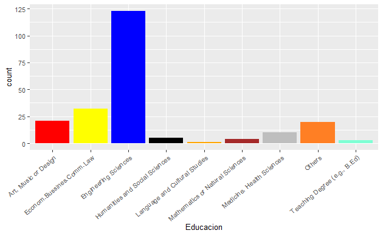

¿Como se asocian las carreras universitarias y la probabilidad de ser empresario?

```r
ctable(df$Educacion, df$y)
```

```
Cross-Tabulation, Row Proportions
Educacion * y
Data Frame: df

--------------------------------- --- -------------- ------------- --------------
                                    y              0             1          Total
                        Educacion
             Art, Music or Design        12 ( 57.1%)    9 ( 42.9%)    21 (100.0%)
         Econom.Bussines.Comm.Law        23 ( 71.9%)    9 ( 28.1%)    32 (100.0%)
             Engineering Sciences        68 ( 55.3%)   55 ( 44.7%)   123 (100.0%)
   Humanities and Social Sciences         0 (  0.0%)    5 (100.0%)     5 (100.0%)
    Language and Cultural Studies         1 (100.0%)    0 (  0.0%)     1 (100.0%)
  Mathematics or Natural Sciences         4 (100.0%)    0 (  0.0%)     4 (100.0%)
        Medicine, Health Sciences         7 ( 70.0%)    3 ( 30.0%)    10 (100.0%)
                           Others        12 ( 60.0%)    8 ( 40.0%)    20 (100.0%)
     Teaching Degree (e.g., B.Ed)         1 ( 33.3%)    2 ( 66.7%)     3 (100.0%)
                            Total       128 ( 58.4%)   91 ( 41.6%)   219 (100.0%)
--------------------------------- --- -------------- ------------- --------------
```

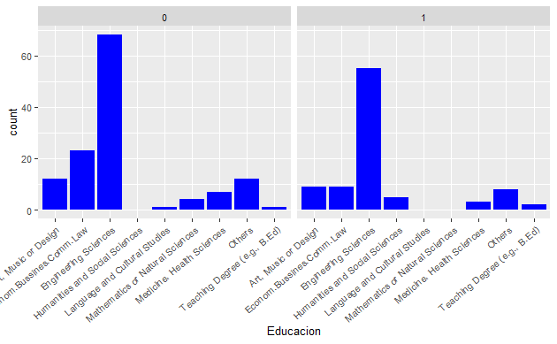

```r
df %>%
group_by(y) %>%
ggplot(aes( x = Educacion)) +
geom_bar(fill = "blue") +
facet_wrap(~y) + theme(text = element_text(size=10),axis.text.x = element_text(angle=40, hjust=1))
```

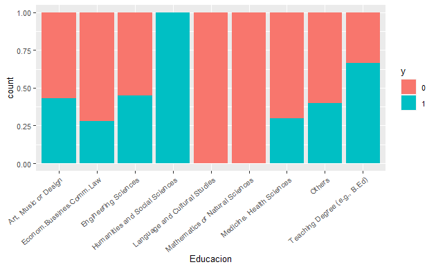

# IndividualProject

Vamos a ver primero cuantos han contestado Si/No a esta pregunta

```r
freq(df$IndividualProject, style = "rmarkdown")
```

```
### Frequencies
#### df$IndividualProject
**Type:** Factor

|     &nbsp; | Freq | % Valid | % Valid Cum. | % Total | % Total Cum. |
|-----------:|-----:|--------:|-------------:|--------:|-------------:|
|     **No** |   95 |   43.38 |        43.38 |   43.38 |        43.38 |
|    **Yes** |  124 |   56.62 |       100.00 |   56.62 |       100.00 |
| **\<NA\>** |    0 |         |              |    0.00 |       100.00 |
|  **Total** |  219 |  100.00 |       100.00 |  100.00 |       100.00 |
```

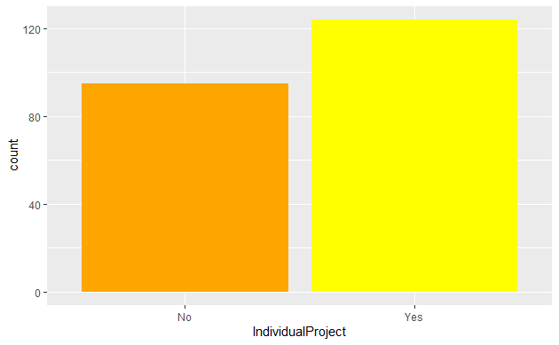

```r
ggplot(df, aes(IndividualProject)) + geom_bar(fill = c("orange", "yellow"))
```

Mas de la mitad han respondido que si iniciarian un proyecto individual.

Vamos a ver como se relaciona esta pregunta con la variable dependiente

```r
ctable(df$IndividualProject, df$y)
```

```
Cross-Tabulation, Row Proportions
IndividualProject * y
Data Frame: df

------------------- --- ------------- ------------ --------------
                      y             0            1          Total
  IndividualProject
                 No        62 (65.3%)   33 (34.7%)    95 (100.0%)
                Yes        66 (53.2%)   58 (46.8%)   124 (100.0%)
              Total       128 (58.4%)   91 (41.6%)   219 (100.0%)
------------------- --- ------------- ------------ --------------
```

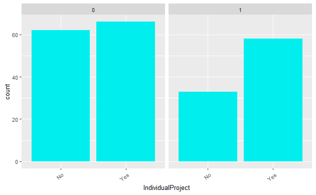

```r
df %>%
group_by(y) %>%
ggplot(aes( x = IndividualProject)) +
geom_bar(fill = "cyan2") +
facet_wrap(~y) + theme(text = element_text(size=10),axis.text.x = element_text(angle=40, hjust=1))
```

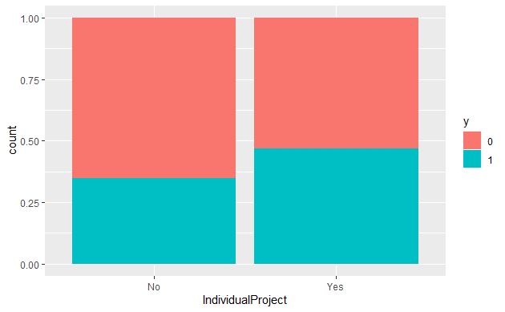

# Age

En primer lugar, vamos a ver como se distribuyen las edades de los que han participado en esta encuensta

```r
freq(df$Age, style = "rmarkdown")
```

```
### Frequencies
#### df$Age
**Type:** Integer

|     &nbsp; | Freq | % Valid | % Valid Cum. | % Total | % Total Cum. |
|-----------:|-----:|--------:|-------------:|--------:|-------------:|
|     **17** |    7 |    3.20 |         3.20 |    3.20 |         3.20 |
|     **18** |   18 |    8.22 |        11.42 |    8.22 |        11.42 |
|     **19** |   70 |   31.96 |        43.38 |   31.96 |        43.38 |
|     **20** |   79 |   36.07 |        79.45 |   36.07 |        79.45 |
|     **21** |   28 |   12.79 |        92.24 |   12.79 |        92.24 |
|     **22** |   12 |    5.48 |        97.72 |    5.48 |        97.72 |
|     **23** |    2 |    0.91 |        98.63 |    0.91 |        98.63 |
|     **24** |    1 |    0.46 |        99.09 |    0.46 |        99.09 |
|     **25** |    1 |    0.46 |        99.54 |    0.46 |        99.54 |
|     **26** |    1 |    0.46 |       100.00 |    0.46 |       100.00 |
| **\<NA\>** |    0 |         |              |    0.00 |       100.00 |
|  **Total** |  219 |  100.00 |       100.00 |  100.00 |       100.00 |
```

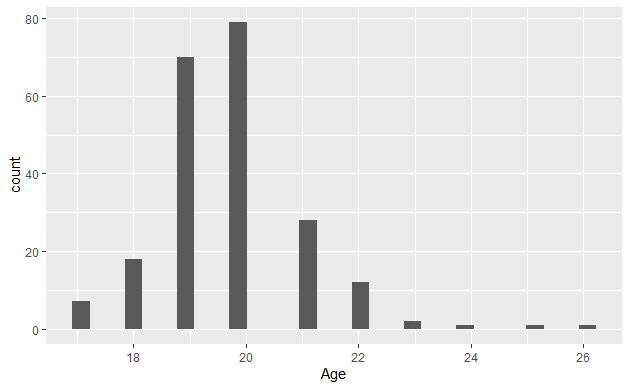

```r
ggplot(df, aes(Age)) + geom_histogram()
```

¿Es la edad un factor determinante para determinar la probabilidad de un universitario de llegar a ser emprendor? Vamos a verlo

```r
ctable(df$Age, df$y)
```

```
Cross-Tabulation, Row Proportions
Age * y
Data Frame: df

------- --- -------------- ------------- --------------
          y              0             1          Total
    Age
     17         5 ( 71.4%)    2 ( 28.6%)     7 (100.0%)
     18        12 ( 66.7%)    6 ( 33.3%)    18 (100.0%)
     19        34 ( 48.6%)   36 ( 51.4%)    70 (100.0%)
     20        47 ( 59.5%)   32 ( 40.5%)    79 (100.0%)
     21        19 ( 67.9%)    9 ( 32.1%)    28 (100.0%)
     22        10 ( 83.3%)    2 ( 16.7%)    12 (100.0%)
     23         0 (  0.0%)    2 (100.0%)     2 (100.0%)
     24         0 (  0.0%)    1 (100.0%)     1 (100.0%)
     25         1 (100.0%)    0 (  0.0%)     1 (100.0%)
     26         0 (  0.0%)    1 (100.0%)     1 (100.0%)
  Total       128 ( 58.4%)   91 ( 41.6%)   219 (100.0%)
------- --- -------------- ------------- --------------
```

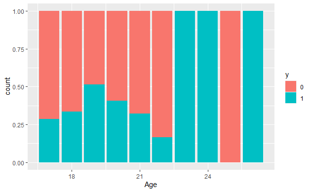

```r
ggplot(df, aes(x = Age, fill = y)) + geom_bar(position = "fill")
```

```r
ctable(df$Rango_edad, df$y)
```

```
Cross-Tabulation, Row Proportions
Rango_edad * y
Data Frame: df

------------ --- ------------- ------------ --------------
               y             0            1          Total
  Rango_edad
       17-19        51 (53.7%)   44 (46.3%)    95 (100.0%)
       20-22        76 (63.9%)   43 (36.1%)   119 (100.0%)
       23-26         1 (20.0%)    4 (80.0%)     5 (100.0%)
       Total       128 (58.4%)   91 (41.6%)   219 (100.0%)
------------ --- ------------- ------------ --------------
```

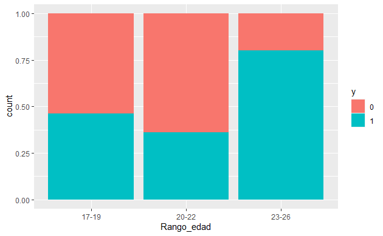

```r
ggplot(df, aes(x = Rango_edad, fill = y)) + geom_bar(position = "fill")
```

Como podemos ver, son los universitarios de mayor edad, los que mas probabilidades tienen de ser emprendedores, no obstante, solo se han encuestado a 5 personas en esta franja de edad, en contraposicion a los 95 y 119 de las otras dos franjas, aqui tenemos un problema de sesgo, seria necesario ampliar el numero de encuestados en la franaja de 23 a 26.

# Gender

Vamos a estudiar ahora el genero, en primer lugar, vamos a ver cuantos han sido encuestados de cada sexo.

```r
freq(df$Gender, style = "rmarkdown")
```

```
### Frequencies
#### df$Gender
**Type:** Factor

|     &nbsp; | Freq | % Valid | % Valid Cum. | % Total | % Total Cum. |
|-----------:|-----:|--------:|-------------:|--------:|-------------:|
| **Female** |   57 |   26.03 |        26.03 |   26.03 |        26.03 |
|   **Male** |  162 |   73.97 |       100.00 |   73.97 |       100.00 |
| **\<NA\>** |    0 |         |              |    0.00 |       100.00 |
|  **Total** |  219 |  100.00 |       100.00 |  100.00 |       100.00 |
```

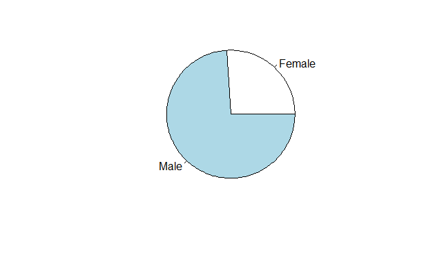

```r
tabla = table(df$Gender)

pie(tabla)
```

¿Tienen mayor probabilidad de ser emprendedor los hombres universitarios o las mujeres universitarias?

```r
ctable(df$Gender, df$y)
```

```
Cross-Tabulation, Row Proportions
Gender * y
Data Frame: df

-------- --- ------------- ------------ --------------
           y             0            1          Total
  Gender
  Female        37 (64.9%)   20 (35.1%)    57 (100.0%)
    Male        91 (56.2%)   71 (43.8%)   162 (100.0%)
   Total       128 (58.4%)   91 (41.6%)   219 (100.0%)
-------- --- ------------- ------------ --------------
```

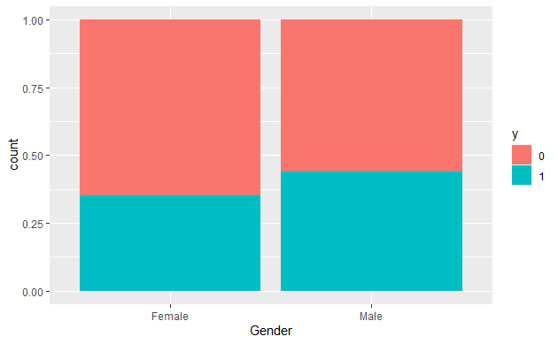

```r
ggplot(df, aes(x = Gender, fill = y)) + geom_bar(position = "fill")
```

Como puede observarse en el grafico los hombres universitarios tienen mayor probabilidad de ser empresarios que las mujeres, no obstante, también podemos apreciar un pequeño problema de sesgo, en esta variable, aunque menor que en el caso anterior.

# City

Vamos a ver cuantos de los universitarios encuestados viven en ciudad y cuantos no.

```r
freq(df$City, style = "rmarkdown")
```

```
### Frequencies
#### df$City
**Type:** Factor

|     &nbsp; | Freq | % Valid | % Valid Cum. | % Total | % Total Cum. |
|-----------:|-----:|--------:|-------------:|--------:|-------------:|
|     **No** |   36 |   16.44 |        16.44 |   16.44 |        16.44 |
|    **Yes** |  183 |   83.56 |       100.00 |   83.56 |       100.00 |
| **\<NA\>** |    0 |         |              |    0.00 |       100.00 |
|  **Total** |  219 |  100.00 |       100.00 |  100.00 |       100.00 |
```

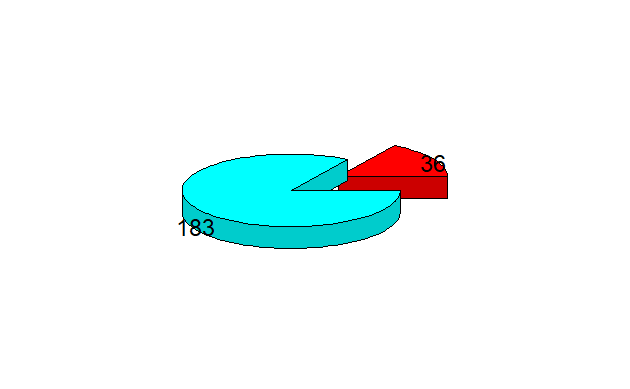

```r
tabla2 = table(df$City)

pie3D(tabla2, labels = tabla2, explode = 0.25)
```

¿Es el lugar de residencia determinante a la hora de que un universitario llegue a ser emprendedor?

```r
ctable(df$City, df$y)
```

```
Cross-Tabulation, Row Proportions
City * y
Data Frame: df

------- --- ------------- ------------ --------------
          y             0            1          Total
   City
     No        24 (66.7%)   12 (33.3%)    36 (100.0%)
    Yes       104 (56.8%)   79 (43.2%)   183 (100.0%)
  Total       128 (58.4%)   91 (41.6%)   219 (100.0%)
------- --- ------------- ------------ --------------
```

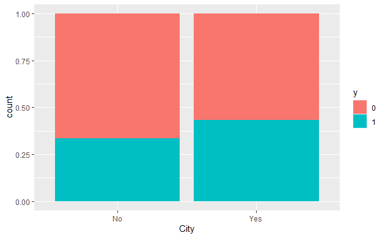

```r
ggplot(df, aes(x = City, fill = y)) + geom_bar(position = "fill")
```

Parece que los universitarios que residen en ciudad tienen mas probabilidad de ser empresarios que los que viven en pueblos (43% - 33%)

# Influenced

De todos los universitarios encuestados, ¿cuantos han elegido su carrera de forma voluntaria y cuantos han sido influenciados para que la elijan ?

```r
freq(df$Influenced, style = "rmarkdown")
```

```
### Frequencies
#### df$Influenced
**Type:** Factor

|     &nbsp; | Freq | % Valid | % Valid Cum. | % Total | % Total Cum. |
|-----------:|-----:|--------:|-------------:|--------:|-------------:|
|     **No** |   61 |   27.85 |        27.85 |   27.85 |        27.85 |
|    **Yes** |  158 |   72.15 |       100.00 |   72.15 |       100.00 |
| **\<NA\>** |    0 |         |              |    0.00 |       100.00 |
|  **Total** |  219 |  100.00 |       100.00 |  100.00 |       100.00 |
```

[figure not shown]

```r
tabla3 = table(df$Influenced)

pie3D(tabla3, labels = tabla2, explode = 0.25)
```

¿En cuanto afecta a la probabilida de ser empresario que la carrera elegida haya sido por influencia y no por propia decision ?

```r
ctable(df$Influenced, df$y)
```

```
Cross-Tabulation, Row Proportions
Influenced * y
Data Frame: df

------------ --- ------------- ------------ --------------
               y             0            1          Total
  Influenced
          No        48 (78.7%)   13 (21.3%)    61 (100.0%)
         Yes        80 (50.6%)   78 (49.4%)   158 (100.0%)
       Total       128 (58.4%)   91 (41.6%)   219 (100.0%)
------------ --- ------------- ------------ --------------
```

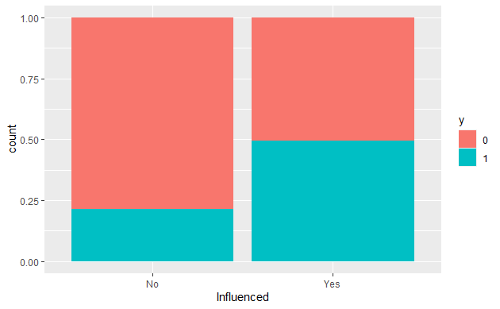

```r
ggplot(df, aes(x = Influenced, fill = y)) + geom_bar(position = "fill")
```

Por lo que se puede observar, los universitarios que son influenciados tienen mayor probabilidad (49.5%) de ser empresarios que los que no (21.3%).

# Perseverance

¿Es la perseverancia un factor a tener en cuenta a la hora de ser empresario?

```r
ctable(df$Perseverance, df$y)
```

```
Cross-Tabulation, Row Proportions
Perseverance * y
Data Frame: df

-------------- --- ------------- ------------ --------------
                 y             0            1          Total
  Perseverance
             1         4 (66.7%)    2 (33.3%)     6 (100.0%)
             2        21 (52.5%)   19 (47.5%)    40 (100.0%)
             3        45 (65.2%)   24 (34.8%)    69 (100.0%)
             4        45 (57.0%)   34 (43.0%)    79 (100.0%)
             5        13 (52.0%)   12 (48.0%)    25 (100.0%)
         Total       128 (58.4%)   91 (41.6%)   219 (100.0%)
-------------- --- ------------- ------------ --------------
```

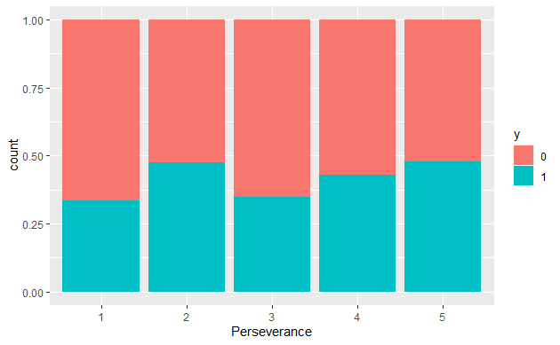

```r
ggplot(df, aes(x = Perseverance, fill = y)) + geom_bar(position = "fill")
```

```r
df = df %>%  mutate(Rango_perseverancia = case_when(between(Perseverance, 1,3) ~ "Bajo", Perseverance >= 4 ~ "Alto"))
```

[output not shown]

```r
df$Rango_perseverancia[is.na(df$Rango_perseverancia)] <- "Alto"
```

Se observa una mayor tendencia de aquellos universitarios, que tienen como rasgo distintivo la perseverancia, a ser catalogados como empresarios (44% frente a 39%)

# DesireToTakeInitiative

¿Es el deseo de tomar la iniciativa determimante para ser emprendedor?

```r
ctable(df$DesireToTakeInitiative, df$y)
```

```
Cross-Tabulation, Row Proportions
DesireToTakeInitiative * y
Data Frame: df

------------------------ --- ------------- ------------ --------------
                           y             0            1          Total
  DesireToTakeInitiative
                       1         8 (66.7%)    4 (33.3%)    12 (100.0%)
                       2        18 (72.0%)    7 (28.0%)    25 (100.0%)
                       3        32 (58.2%)   23 (41.8%)    55 (100.0%)
                       4        38 (55.1%)   31 (44.9%)    69 (100.0%)
                       5        32 (55.2%)   26 (44.8%)    58 (100.0%)
                   Total       128 (58.4%)   91 (41.6%)   219 (100.0%)
------------------------ --- ------------- ------------ --------------
```

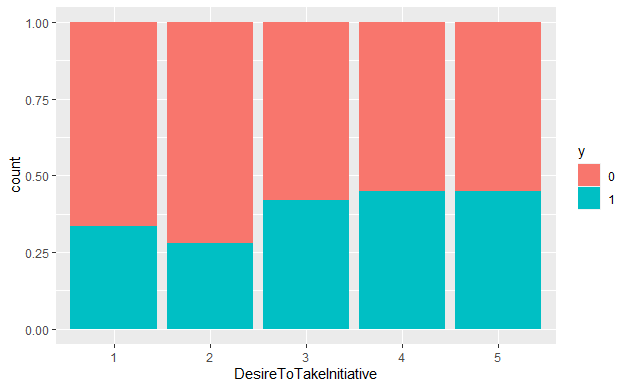

```r
ggplot(df, aes(x = DesireToTakeInitiative, fill = y)) + geom_bar(position = "fill")
```

Se observa una leve relacion entre el mayor deseo de tomar la iniciativa y la probabilidad de ser emprendedor.

```r
df = df %>%  mutate(Rango_Iniciativa = case_when(between(DesireToTakeInitiative, 1,3) ~ "Bajo", DesireToTakeInitiative >= 4 ~ "Alto"))
```

[output not shown]

```r
df$Rango_Iniciativa[is.na(df$Rango_Iniciativa)] <- "Alto"
```

Podemos ver como los universitarios con un nivel mas alto de deseo de tomar la iniciativa, tienen mas probabilidad de ser catalogados como empresarios (45% frente al 37%)

# Competitiveness

¿Son los universitarios mas competitivos los que mas probabilidad tienen de ser empresarios?

```r
ctable(df$Competitiveness, df$y)
```

```
Cross-Tabulation, Row Proportions
Competitiveness * y
Data Frame: df

----------------- --- ------------- ------------ --------------
                    y             0            1          Total
  Competitiveness
                1         4 (44.4%)    5 (55.6%)     9 (100.0%)
                2        13 (50.0%)   13 (50.0%)    26 (100.0%)
                3        45 (68.2%)   21 (31.8%)    66 (100.0%)
                4        39 (61.9%)   24 (38.1%)    63 (100.0%)
                5        27 (49.1%)   28 (50.9%)    55 (100.0%)
            Total       128 (58.4%)   91 (41.6%)   219 (100.0%)
----------------- --- ------------- ------------ --------------
```

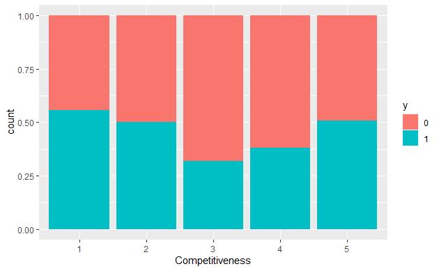

```r
ggplot(df, aes(x = Competitiveness, fill = y)) + geom_bar(position = "fill")
```

```r
df = df %>%  mutate(Rango_Competitividad = case_when(between(Competitiveness, 1,3) ~ "Bajo", Competitiveness >= 4 ~ "Alto"))
```

[output not shown]

```r
df$Rango_Competitividad[is.na(df$Rango_Competitividad)] <- "Alto"
```

# SelfReliance

¿Un mayor nivel de autosuficiencia determina una mayor probabilidad de ser empresario?

```r
ctable(df$SelfReliance, df$y)
```

```
Cross-Tabulation, Row Proportions
SelfReliance * y
Data Frame: df

-------------- --- ------------- ------------ --------------
                 y             0            1          Total
  SelfReliance
             1         4 (66.7%)    2 (33.3%)     6 (100.0%)
             2        17 (70.8%)    7 (29.2%)    24 (100.0%)
             3        29 (55.8%)   23 (44.2%)    52 (100.0%)
             4        48 (60.0%)   32 (40.0%)    80 (100.0%)
             5        30 (52.6%)   27 (47.4%)    57 (100.0%)
         Total       128 (58.4%)   91 (41.6%)   219 (100.0%)
-------------- --- ------------- ------------ --------------
```

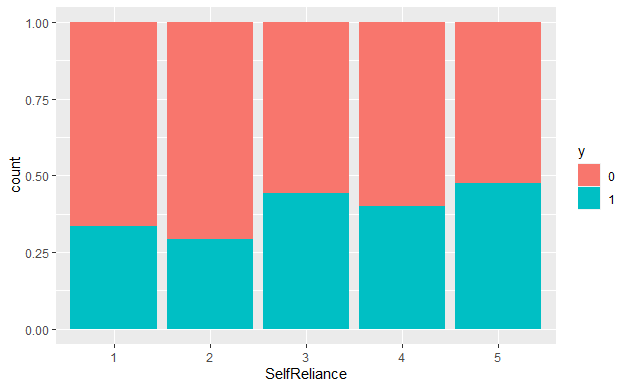

```r
ggplot(df, aes(x = SelfReliance, fill = y)) + geom_bar(position = "fill")
```

Por lo que se observa en la grafica, podemos decir que un mayor nivel de autosuficiencia, aumenta la probabilidad de ser empresario. Vamos a crear una variable binomial

```r
df = df %>%  mutate(Rango_autosuficiencia = case_when(between(SelfReliance, 1,3) ~ "Bajo", SelfReliance >= 4 ~ "Alto"))
```

[output not shown]

```r
df$Rango_autosuficiencia[is.na(df$Rango_autosuficiencia)] <- "Alto"
```

# StrongNeedToAchieve

```r
ctable(df$StrongNeedToAchieve, df$y)
```

```
Cross-Tabulation, Row Proportions
StrongNeedToAchieve * y
Data Frame: df

--------------------- --- ------------- ------------ --------------
                        y             0            1          Total
  StrongNeedToAchieve
                    1         1 (50.0%)    1 (50.0%)     2 (100.0%)
                    2        14 (66.7%)    7 (33.3%)    21 (100.0%)
                    3        34 (68.0%)   16 (32.0%)    50 (100.0%)
                    4        34 (50.0%)   34 (50.0%)    68 (100.0%)
                    5        45 (57.7%)   33 (42.3%)    78 (100.0%)
                Total       128 (58.4%)   91 (41.6%)   219 (100.0%)
--------------------- --- ------------- ------------ --------------
```

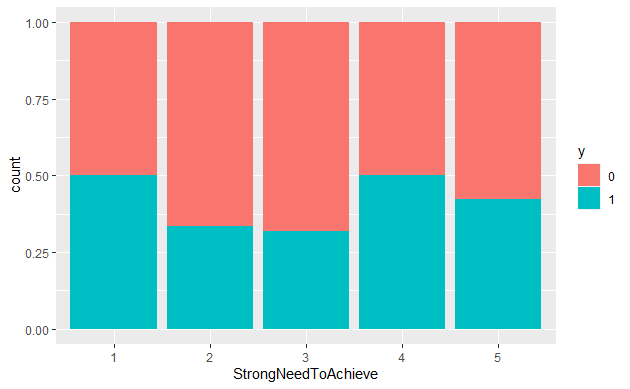

```r
ggplot(df, aes(x = StrongNeedToAchieve, fill = y)) + geom_bar(position = "fill")
```

```r
df = df%>% mutate(Rango_meta = case_when(between(StrongNeedToAchieve, 1,3) ~ "Bajo", StrongNeedToAchieve >= 4 ~ "Alto"))
```

[output not shown]

```r
df$Rango_meta[is.na(df$Rango_meta)] <- "Alto"
```

# SelfConfidence

¿Un mayor nivel de autoconfianza genera una mayor probabilidad de ser empreario?

```r
ctable(df$SelfConfidence, df$y)
```

```
Cross-Tabulation, Row Proportions
SelfConfidence * y
Data Frame: df

---------------- --- ------------- ------------ --------------
                   y             0            1          Total
  SelfConfidence
               1         4 (44.4%)    5 (55.6%)     9 (100.0%)
               2        22 (71.0%)    9 (29.0%)    31 (100.0%)
               3        37 (66.1%)   19 (33.9%)    56 (100.0%)
               4        37 (52.1%)   34 (47.9%)    71 (100.0%)
               5        28 (53.8%)   24 (46.2%)    52 (100.0%)
           Total       128 (58.4%)   91 (41.6%)   219 (100.0%)
---------------- --- ------------- ------------ --------------
```

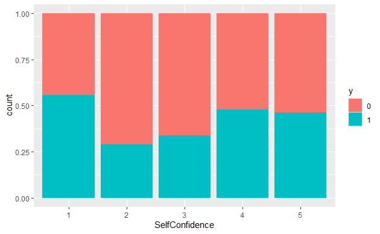

```r
ggplot(df, aes(x = SelfConfidence, fill = y)) + geom_bar(position = "fill")
```

Los resultados, como se pueden ver en la grafica, no son relevantes, vamos a hacer lo mismo que en la variable anterior, divir los niveles en dos y observar de nuevo los resultados.

```r
df = df%>% mutate(Rango_autoconfianza = case_when(between(SelfConfidence, 1,3) ~ "Bajo", SelfConfidence >= 4 ~ "Alto"))
```

[output not shown]

```r
df$Rango_autoconfianza[is.na(df$Rango_autoconfianza)] <- "Alto"
```

Ahora si, podemos observar como los universitarios con un nivel de autoconfianza mayor, tienen mas probabilidades de ser emoresarios (47% frente a un 34,5%)

# GoodPhysicalHealth

Antes de nada, vamos a crear la categoria doble (baja/alta)

```r
df = df%>% mutate(Rango_salud_fisica = case_when(between(GoodPhysicalHealth, 1,3) ~ "Bajo", GoodPhysicalHealth >= 4 ~ "Alto"))
```

[output not shown]

```r
df$Rango_salud_fisica[is.na(df$Rango_salud_fisica)] <- "Alto"
```

# MentalDisorder

¿Tener algun trastorno mental determina la probabilidad de ser empresario?

```r
ctable(df$MentalDisorder, df$y)
```

```
Cross-Tabulation, Row Proportions
MentalDisorder * y
Data Frame: df

---------------- --- ------------- ------------ --------------
                   y             0            1          Total
  MentalDisorder
              No        91 (58.7%)   64 (41.3%)   155 (100.0%)
             Yes        37 (57.8%)   27 (42.2%)    64 (100.0%)
           Total       128 (58.4%)   91 (41.6%)   219 (100.0%)
---------------- --- ------------- ------------ --------------
```

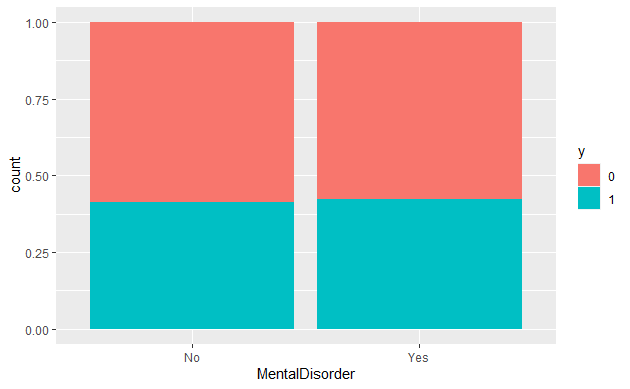

```r
ggplot(df, aes(x = MentalDisorder, fill = y)) + geom_bar(position = "fill")
```

Se observa unos valores muy parejos, tanto para aquellos universitarios que presentan algun transtorno mental, como para los que no. Esta variable la vamos a descartar al no ser muy relevante.

# KeyTraits

¿De los rasgos analizados en esta pregunta, hay alguno que sea mas propenso para los empresarios?

```r
ctable(df$KeyTraits, df$y)
```

```
Cross-Tabulation, Row Proportions
KeyTraits * y
Data Frame: df

------------ --- ------------- ------------ --------------
               y             0            1          Total
   KeyTraits
     Passion        40 (64.5%)   22 (35.5%)    62 (100.0%)
  Positivity        40 (54.8%)   33 (45.2%)    73 (100.0%)
  Resilience         9 (90.0%)    1 (10.0%)    10 (100.0%)
      Vision        18 (51.4%)   17 (48.6%)    35 (100.0%)
  Work Ethic        21 (53.8%)   18 (46.2%)    39 (100.0%)
       Total       128 (58.4%)   91 (41.6%)   219 (100.0%)
------------ --- ------------- ------------ --------------
```

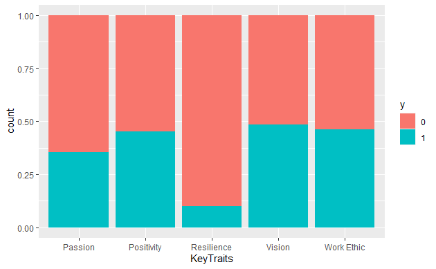

```r
ggplot(df, aes(x = KeyTraits, fill = y)) + geom_bar(position = "fill")
```

Podemos ver como la positividad, vision y trabajo etico, son rasgos que destacan de los emprendedores, mientras que la resiliencia es un rasgo poco usual en los emprendedores.

# ReasonsForLack

MOtivos en la falta de interes en ser emprendedor

¿Hay algun motivo determinante, a la hora de que sean catalogados los universitarios sin probabilidad de ser emprendedores?

```r
unique(df$ReasonsForLack)
```

```
 [1]
 [2] Just not interested! (Want to work in the corporate sector, or for the government or pursue research or something else)
 [3] Not willing to start a venture in India and waiting for future relocation
 [4] Not able to take a Financial Risk
 [5] Just not interested! (Want to work in the corporate sector, or for the government or pursue research or something else), Academic Pressure, Lack of Knowledge, Not able to take a Financial Risk
 [6] Academic Pressure, Lack of Knowledge, Not able to take a Financial Risk
 [7] Just not interested! (Want to work in the corporate sector, or for the government or pursue research or something else), Academic Pressure, Parental Pressure
 [8] Academic Pressure, Lack of Knowledge, Mental Block
 [9] Lack of Knowledge
[10] Academic Pressure, Unwillingness to take risk, Lack of Knowledge
[11] Just not interested! (Want to work in the corporate sector, or for the government or pursue research or something else), Lack of Knowledge, Parental Pressure, Mental Block
[12] Unwillingness to take risk, Lack of Knowledge, Not able to take a Financial Risk
[13] Just not interested! (Want to work in the corporate sector, or for the government or pursue research or something else), Unwillingness to take risk, Lack of Knowledge
[14] Just not interested! (Want to work in the corporate sector, or for the government or pursue research or something else), Academic Pressure, Unwillingness to take risk, Lack of Knowledge, Parental Pressure, Not able to take a Financial Risk
[15] Academic Pressure, Lack of Knowledge
```

[output cut: 31 more lines]

```r
table(df$ReasonsForLack)
```

[output not shown]

[output cut: 72 more lines]

No se trata de una variable que aporte mucha informacion, por lo que la vamos a eliminar.

# Indicios encontrados

# Creacion de un modelo

```r
df_2 = select(df,EducationSector, IndividualProject, Rango_edad, Gender, City, Influenced, Rango_perseverancia,
Rango_Iniciativa, Rango_Competitividad, Rango_autosuficiencia,
Rango_meta, Rango_autoconfianza, KeyTraits, y)
```

[output not shown]

Vamos a generar un modelo con estas variables

```r
modelo = glm(y ~ EducationSector + IndividualProject + Rango_edad + Gender + City + Influenced + Rango_perseverancia + Rango_Iniciativa + Rango_Competitividad + Rango_autosuficiencia + Rango_meta + Rango_autoconfianza + KeyTraits,  data = df, family = binomial)

summary(modelo)
```

```
Call:
glm(formula = y ~ EducationSector + IndividualProject + Rango_edad +
    Gender + City + Influenced + Rango_perseverancia + Rango_Iniciativa +
    Rango_Competitividad + Rango_autosuficiencia + Rango_meta +
    Rango_autoconfianza + KeyTraits, family = binomial, data = df)

Deviance Residuals:
    Min       1Q   Median       3Q      Max
-1.8569  -0.9026  -0.4390   1.0309   1.9762

Coefficients:
                                                                       Estimate
(Intercept)                                                            -2.07306
EducationSectorEconomic Sciences, Business Studies, Commerce and Law   -0.74964
EducationSectorEngineering Sciences                                     0.30528
EducationSectorHumanities and Social Sciences                          18.32424
EducationSectorLanguage and Cultural Studies                          -18.05193
EducationSectorMathematics or Natural Sciences                        -17.87018
EducationSectorMedicine, Health Sciences                               -0.10795
EducationSectorOthers                                                   0.26601
EducationSectorTeaching Degree (e.g., B.Ed)                             0.49863
IndividualProjectYes                                                    0.82245
Rango_edad20-22                                                        -0.79690
Rango_edad23-26                                                         1.81658
GenderMale                                                              0.19414
CityYes                                                                 0.36995
InfluencedYes                                                           1.25582
Rango_perseveranciaBajo                                                 0.02155
Rango_IniciativaBajo                                                   -0.15835
Rango_CompetitividadBajo                                                0.13913
Rango_autosuficienciaBajo                                               0.38233
Rango_metaBajo                                                         -0.43590
Rango_autoconfianzaBajo                                                -0.32454
KeyTraitsPositivity                                                     0.46730
KeyTraitsResilience                                                    -1.57109
KeyTraitsVision                                                         0.56596
KeyTraitsWork Ethic                                                     0.26249
                                                                     Std. Error
(Intercept)                                                             0.87354
EducationSectorEconomic Sciences, Business Studies, Commerce and Law    0.71335
```

[output cut: 96 more lines]

```
Rango_autoconfianzaBajo
KeyTraitsPositivity
KeyTraitsResilience
KeyTraitsVision
KeyTraitsWork Ethic
---
Signif. codes:  0 ‘***’ 0.001 ‘**’ 0.01 ‘*’ 0.05 ‘.’ 0.1 ‘ ’ 1

(Dispersion parameter for binomial family taken to be 1)

    Null deviance: 297.32  on 218  degrees of freedom
Residual deviance: 239.55  on 194  degrees of freedom
AIC: 289.55

Number of Fisher Scoring iterations: 16
```

```r
modelo_final= step(modelo, direction="backward")
```

```
Start:  AIC=289.55
y ~ EducationSector + IndividualProject + Rango_edad + Gender +
    City + Influenced + Rango_perseverancia + Rango_Iniciativa +
    Rango_Competitividad + Rango_autosuficiencia + Rango_meta +
    Rango_autoconfianza + KeyTraits

                        Df Deviance    AIC
- KeyTraits              4   244.82 286.82
- Rango_perseverancia    1   239.56 287.56
- Rango_Competitividad   1   239.63 287.63
- Rango_Iniciativa       1   239.67 287.67
- Gender                 1   239.79 287.79
- Rango_autoconfianza    1   240.01 288.01
- Rango_autosuficiencia  1   240.07 288.07
- City                   1   240.15 288.15
- Rango_meta             1   240.17 288.17
<none>                       239.55 289.55
- IndividualProject      1   245.21 293.20
- Rango_edad             2   247.75 293.75
- EducationSector        8   261.95 295.95
- Influenced             1   250.52 298.52

Step:  AIC=286.82
y ~ EducationSector + IndividualProject + Rango_edad + Gender +
    City + Influenced + Rango_perseverancia + Rango_Iniciativa +
    Rango_Competitividad + Rango_autosuficiencia + Rango_meta +
    Rango_autoconfianza

                        Df Deviance    AIC
- Rango_perseverancia    1   244.82 284.82
- Rango_Competitividad   1   244.99 284.99
- Rango_Iniciativa       1   245.02 285.02
- Gender                 1   245.28 285.28
- Rango_autosuficiencia  1   245.43 285.43
- Rango_meta             1   245.63 285.63
- Rango_autoconfianza    1   245.72 285.72
- City                   1   246.14 286.14
<none>                       244.82 286.82
- IndividualProject      1   249.75 289.75
- Rango_edad             2   252.75 290.75
```

[output cut: 95 more lines]

```
- Rango_edad           2   255.98 281.98
- EducationSector      8   269.66 283.66
- Influenced           1   260.19 288.19

Step:  AIC=276.14
y ~ EducationSector + IndividualProject + Rango_edad + Influenced +
    Rango_autoconfianza

                      Df Deviance    AIC
<none>                     248.14 276.14
- Rango_autoconfianza  1   250.25 276.25
- IndividualProject    1   253.62 279.62
- Rango_edad           2   257.08 281.08
- EducationSector      8   271.03 283.03
- Influenced           1   261.13 287.13
```

```r
modelo_final
```

```
Call:  glm(formula = y ~ EducationSector + IndividualProject + Rango_edad +
    Influenced + Rango_autoconfianza, family = binomial, data = df)

Coefficients:
                                                         (Intercept)
                                                            -1.32825
EducationSectorEconomic Sciences, Business Studies, Commerce and Law
                                                            -0.83384
                                 EducationSectorEngineering Sciences
                                                             0.35263
                       EducationSectorHumanities and Social Sciences
                                                            17.31617
                        EducationSectorLanguage and Cultural Studies
                                                           -16.52554
                      EducationSectorMathematics or Natural Sciences
                                                           -16.31142
                            EducationSectorMedicine, Health Sciences
                                                             0.02408
                                               EducationSectorOthers
                                                             0.17480
                         EducationSectorTeaching Degree (e.g., B.Ed)
                                                             0.67678
                                                IndividualProjectYes
                                                             0.76321
                                                     Rango_edad20-22
                                                            -0.77041
                                                     Rango_edad23-26
                                                             1.77163
                                                       InfluencedYes
                                                             1.28772
                                             Rango_autoconfianzaBajo
                                                            -0.45323

Degrees of Freedom: 218 Total (i.e. Null);  205 Residual
Null Deviance:      297.3
Residual Deviance: 248.1    AIC: 276.1
```